# Exploratory analyses I

PCB 6455 / BSC 4933: Biometry | Lecture 5

Dr. Brian Maitner

## Today’s agenda

1. Get the course repository
2. Discuss data of interest
3. Exploratory analyses and graphics
4. Work through 2.6

## The story so far

**Lecture 3:** three ways to do statistics, and data we simulated ourselves.

**Lecture 4:** reading real data into R, and checking that R read it right.

**Today:** looking at the data before modeling it.

# Why explore?

## Exploratory analyses and graphics

Why do we do exploratory analyses and graphing?

| Reason | For example |
| --- | --- |
| **Detect errors** | nonsensical values, perfect correlations, “weird” patterns |
| **Understand distributions, check assumptions** | non-normal data where a test assumes normal |
| **Find patterns and relationships** | mapping variables, pairwise correlation plots |
| **Identify variables to drop** | highly correlated variables (in some cases) |

**A critical part of science!**

# Get the course repository

## Last time you downloaded one file

Today you need several, and I’ll add more all semester.

There’s a better way: **get the whole repository at once, and update it with one click.**

github.com/bmaitner/biometry_course

## Cloning a repository

The same steps as your own repository in Lecture 2, with a different address.

**In RStudio:** File → New Project… → Version Control → Git

Paste `https://github.com/bmaitner/biometry_course`

Pick a folder. Create Project.

*(Big download: start it now, and we’ll keep going while it runs.)*

## Why a Project, not just a folder

Class scripts use paths like:

```r
read.csv("data/Avonet/AVONET1_BirdLife.csv")
```

Those only work if R is *in* the right folder. Opening the repository as a Project is what puts you there.

None of the confusion of looking for your files!

## Getting updates later

I add lectures, scripts and data as we go. To get them:

**Git tab → Pull** (the blue down arrow)

Do this before every class.

## Don’t edit existing files in this folder

If you change a script here, the next Pull may refuse to run. That can be fixed, but it’s a hassle.

**Instead:** copy what you want into your own project, then edit it there. Or make a folder with your name on it in this one: nothing in it will be overwritten.

Treat the code and data I’ve provided as read-only.

# Data of interest

## What types of data are we interested in?

Let’s go around: what kinds of data, and what questions? You’ll be choosing one or more focal datasets to work with.

In particular, tell us **if you already have data**, or **if you need help finding some**.

Have a look in `data/` in the repository you just cloned: each folder has a README.

# Exploratory graphics

## Which plot?

It depends on what kind of variables you have.

| Predictor | Response | Plot |
| --- | --- | --- |
| none | one continuous | `hist()`, `boxplot()` |
| one categorical | one continuous | `boxplot()` |
| one continuous | one continuous | `plot()` |
| none | one categorical | `table()`, `barplot()` |
| two categorical |  | `table()`, `mosaicplot()` |

Bolker’s Table 2.1 is the long version.

## Start with one continuous variable

Make sure you’re in the **biometry_course** project: check the top right.

[figure not shown]

```r
avonet <- read.csv("data/Avonet/AVONET1_BirdLife.csv")
hist(avonet$Mass)
```

The first line is last week’s, now with the file already in place.

## That’s one bar

This is not broken. It’s telling you the truth, badly.

10,995 of 11,009 species (99.9%) are in that first bin.

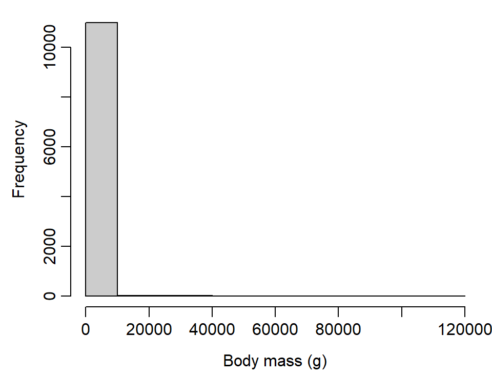

## Why?

```r
range(avonet$Mass)
```

**Check:** 1.9 and 111,000

| Smallest | Largest |
| --- | --- |
| Peruvian sheartail, *Thaumastura cora*: 1.9 g | Ostrich, *Struthio camelus*: 111,000 g |

A 58,000-fold range. The median is 35.5 g.

## Log scaling and body size

[figure not shown]

```r
hist(log10(avonet$Mass),
     breaks = 40)
```

Kerkhoff and Enquist (2009), *Journal of Theoretical Biology* 257: 519–521

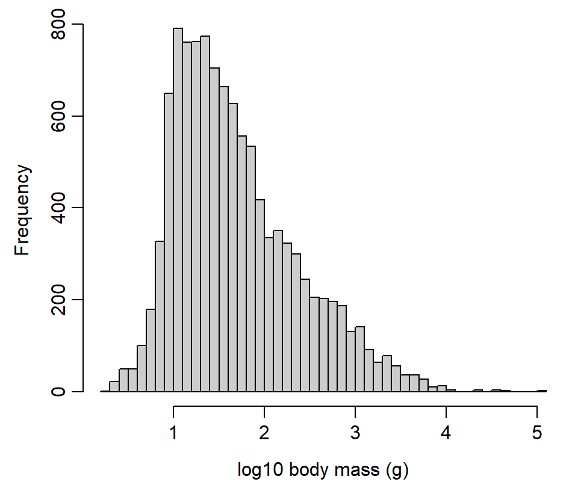

## Two continuous variables

```r
plot(x = avonet$Mass,
     y = avonet$Wing.Length)
cor(avonet$Mass,
    avonet$Wing.Length,
    use = "complete.obs")
```

**What is the correlation?**

**Check:** 0.35

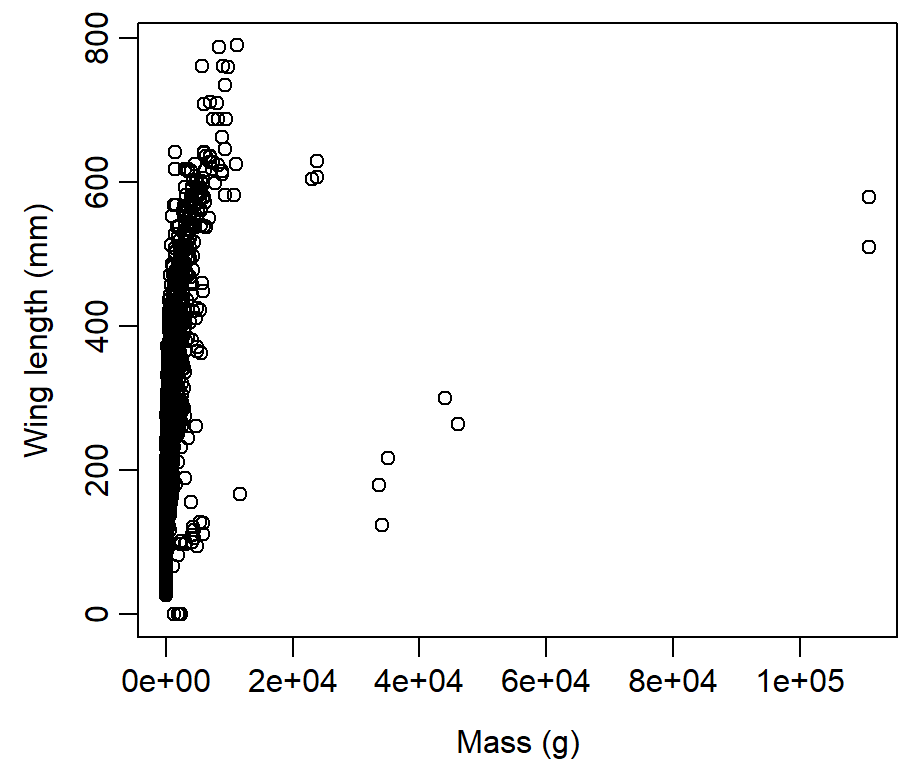

## The same data, log-log

```r
plot(x = avonet$Mass,
     y = avonet$Wing.Length,
     log = "xy")
```

**What is the correlation now?** Hint: use the `log()` function.

**Check:** `cor(log(avonet$Mass), log(avonet$Wing.Length))` is 0.89

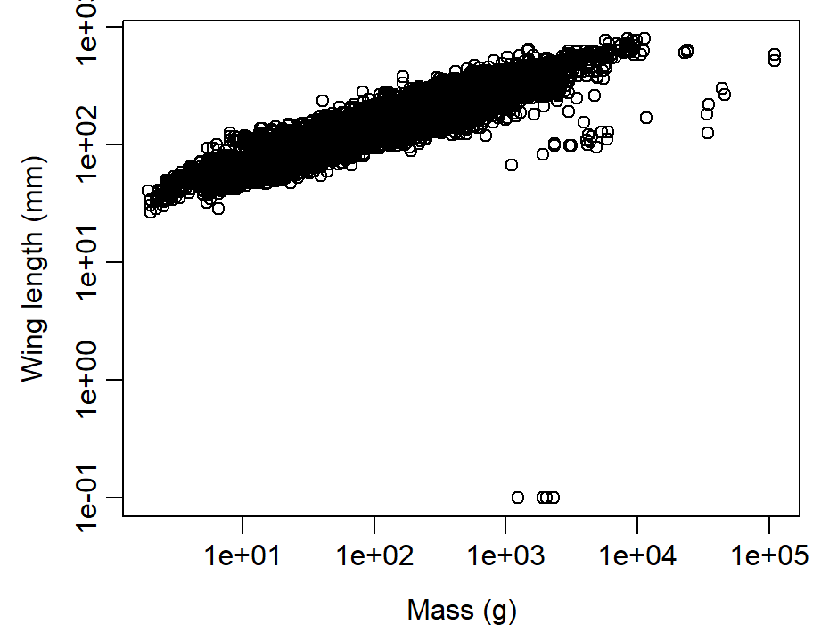

Same data, same species, same function. The plot didn’t just look nicer: it changed the answer.

## What birds are those?

Any guesses?

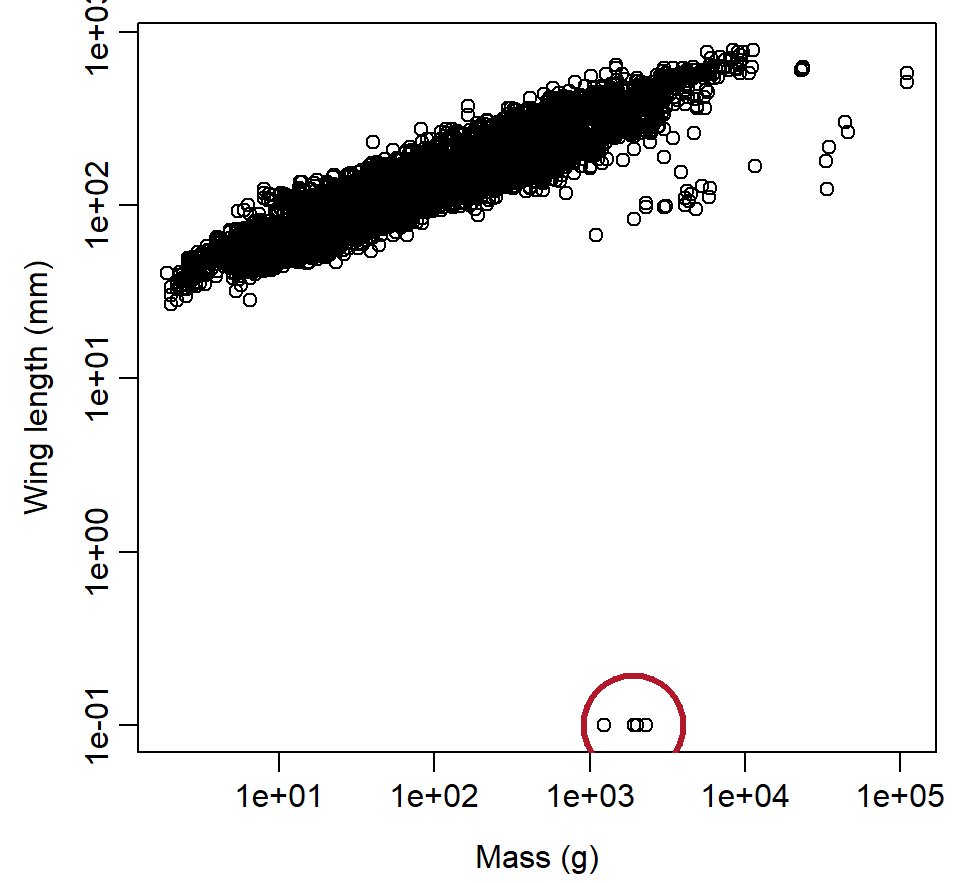

## Kiwis

```r
avonet[which(avonet$Wing.Length < 1),
       c("Species1", "Family1", "Mass", "Wing.Length")]
```

```
               Species1     Family1   Mass Wing.Length
10853 Apteryx australis Apterygidae 2320.5         0.1
10854   Apteryx haastii Apterygidae 2022.7         0.1
10855  Apteryx mantelli Apterygidae 2320.5         0.1
10856    Apteryx owenii Apterygidae 1238.3         0.1
10857      Apteryx rowi Apterygidae 1924.0         0.1
```

0.1 is a placeholder for “too small to measure.”

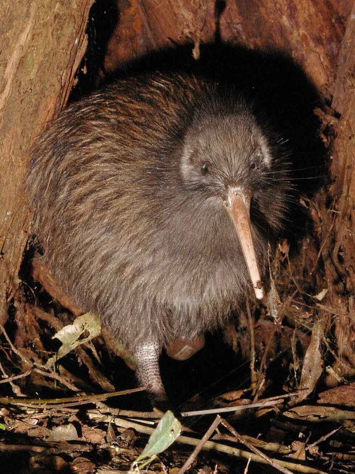

*Apteryx mantelli*  
Photo: Maungatautari Ecological Island Trust, public domain

## What birds are those?

Any guesses?

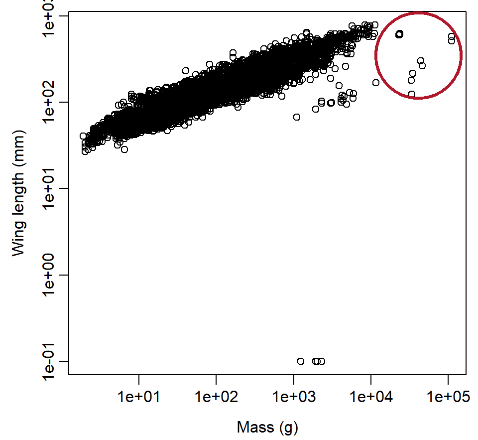

## Outlier is not the same as error

```r
avonet[which(avonet$Mass > 20000),
       c("Species1", "Mass", "Wing.Length")]
```

```
                        Species1     Mass Wing.Length
10597       Aptenodytes forsteri  33569.3       179.4
10858         Casuarius bennetti  35000.0       216.8
10859        Casuarius casuarius  44000.0       300.8
10860 Casuarius unappendiculatus  46073.9       264.5
10861   Dromaius novaehollandiae  34093.3       124.5
10862             Rhea americana  23000.0       604.5
10863               Rhea pennata  23900.0       629.5
10864          Rhea tarapacensis  23900.0       607.0
10865           Struthio camelus 111000.0       579.0
10866     Struthio molybdophanes 111000.0       510.5
```

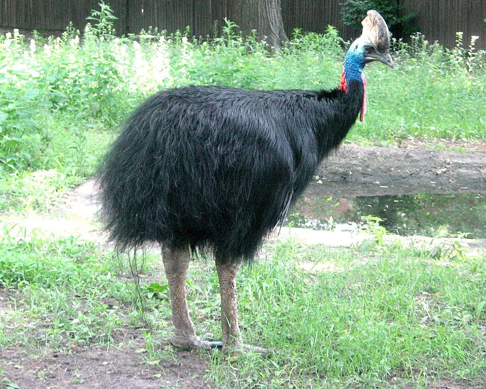

*Casuarius casuarius*  
Photo: DoroshenkoE, Kyiv Zoo, public domain

**Also extreme. Also flightless. These are real measurements.**

## Too many points

```r
plot(x = avonet$Mass,
     y = avonet$Wing.Length,
     log = "xy",
     pch = 16,
     cex = 0.4,
     col = rgb(0, 0, 0, alpha = 0.3))
```

**`cex`** sets the point size. **`alpha`** sets the transparency.

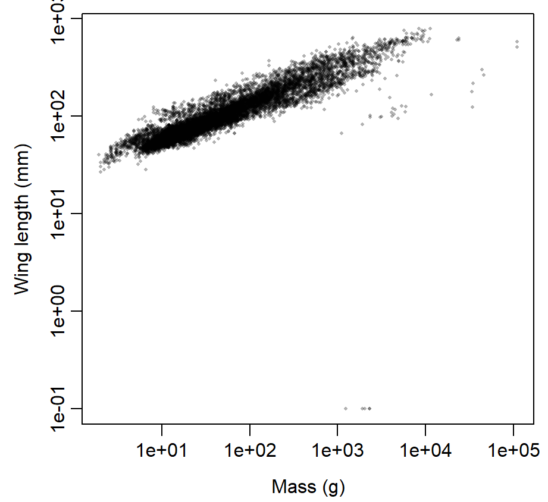

Now you can see where the points are densest.

## A categorical predictor

```r
boxplot(log10(Mass) ~ Trophic.Level,
        data = avonet)
```

**Which trophic level is the largest?**

`~` means “as a function of”. You’ll see this notation all semester.

`data = avonet` saves typing `avonet$` in front of every column.

**Check:** scavengers, with a median around 5,515 g.

## One categorical variable

**Try both. Which is more informative?**

```r
table(avonet$Habitat)
barplot(sort(table(avonet$Habitat),
             decreasing = TRUE),
        las = 2)
```

`las = 2` turns the labels sideways (las: label axis style).

## Numbers that aren’t quantities

Migration is coded 1, 2, 3 (sedentary, partial, migratory).

```r
mean(avonet$Migration)
mean(avonet$Migration, na.rm = TRUE)
```

**What do you get?**

**Check:** `NA`, then 1.29

## Numbers that aren’t quantities

R doesn’t know what a column means. That’s up to you.

**What class is R treating Migration as?** Then try both fixes:

```r
class(avonet$Migration)
barplot(table(avonet$Migration))
avonet$Migration <- as.factor(avonet$Migration)
class(avonet$Migration)
```

**Check:** `"integer"`, then `"factor"`

R checks types, not meaning. Only you know that a column of numbers is really a code.

# Wrapping up

## Which tool, when

| You want to see | Use |
| --- | --- |
| one continuous variable | `hist()`, with `log10()` if it spans orders of magnitude |
| two continuous variables | `plot(x, y)`, with `log = "xy"` if needed; `cor()` for a number |
| a continuous variable by group | `boxplot(y ~ group, data = )` |
| one categorical variable | `table()`, `barplot(sort(table()))` |
| the rows behind odd points | `data[which(condition), columns]` |
| many overlapping points | `pch = 16`, `cex =`, `col = rgb(0, 0, 0, alpha = )` |
| a code treated as a category | `as.factor()` |

## Remainder of class: work through 2.6

Start at **2.6.2** (the plots). Skip the reconstruction in 2.6.1: one line gets you the finished dataset.

```r
install.packages("emdbook")
```

```r
library(emdbook)
data(SeedPred)
str(SeedPred)
```

The chapter’s code is in `R_scripts/Chapter_2_examples.R`, in the repository you just cloned.

## Before next class

Review Bolker **2.5 to 2.6**

Next class: discuss Assignment 1 and potential data sources, continue working through 2.6, and start applying chapter 2 to your own data